# Análise Agregados Monetários

## Alíquota de compulsório

Como a série não está disponível no sistema de séries, fiz o download da planilha no [site do BCB](https://www.bcb.gov.br/htms/infecon/seriehistreccomp_p.asp) e arrumei ela manualmente antes de importar para o R (dá para fazer a limpeza dos dados no R, mas ia tomar um tempinho considerável). Se você for tentar reproduzir o código, terá que alterar o caminho para o arquivo. Se quiser usar a minha planilha, ela está disponível [aqui](https://github.com/aishameriane/Stuff/tree/master/Monetaria).

```r
compulsorio <- data.frame(read_excel("C:\\Users\\Aishameriane\\OneDrive\\Documentos\\Graduação Economia UDESC\\2018-1\\Economia Monetária UFSC - Roberto Meurer\\Agregados Monetários\\compulsorios2.xls"))
df4 <- data.frame(seq(as.Date("1992-12-01"), length = length(compulsorio[,2]), by = "1 month"), compulsorio[,2])
names(df4) <- c("Data", "compulsorio")

p4 <- ggplot(df4, aes(Data))+
        geom_line(aes(y = compulsorio), colour = cores[4]) +
        scale_x_date(date_breaks = "24 months", name = "Data", labels = date_format("%m-%Y"))+
        scale_y_continuous(name = "Alíquota (%)")+
        theme_bw() + theme(axis.text.x = element_text(angle=30, hjust = 1, size = 7))+
        labs(title = "Alíquota de Depósitos Compulsórios (%)")
```

No gráfico do compulsório temos que em 1994 houve uma alíquota de 100% (marginal sobre os acréscimos de depósitos à vista). Vimos no gráfico do M1 que em 94 a demanda por moeda aumentou bastante e com isso as pessoas deixaram bastante dinheiro no banco, mas com o compulsório de 100% isso fez com que os empréstimos não aumentassem. Com a eleição do Lula o compulsório subiu.

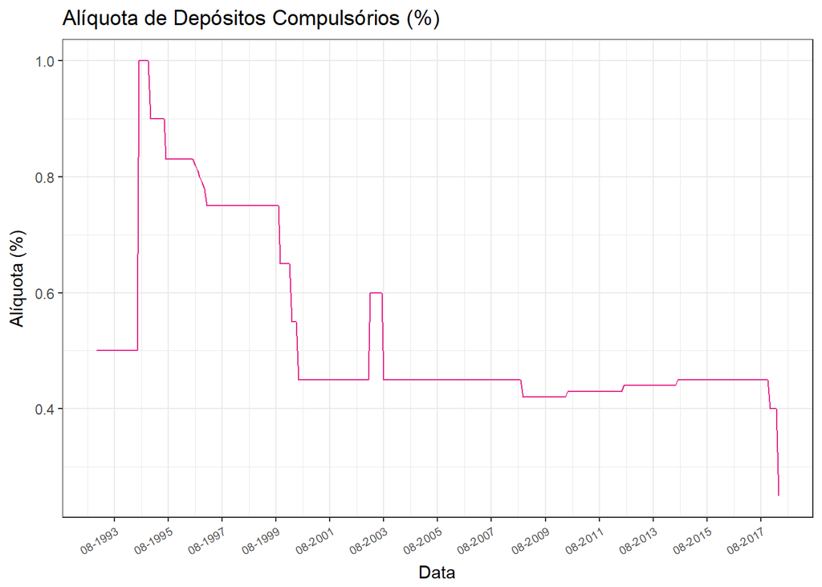

```r
p4
```

Agora vamos tentar plotar o compulsório e o multiplicador monetário juntos.

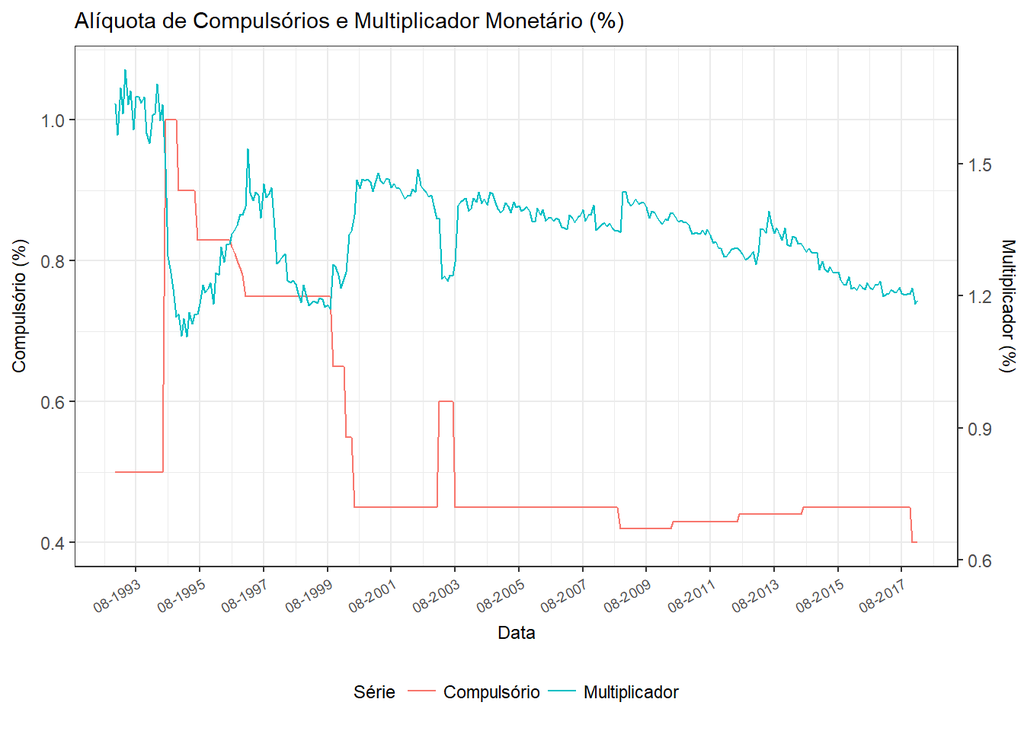

```r
df5 <- data.frame(seq(as.Date("1992-12-01"), length = length(window(mm, c(1992,12))), by = "1 month"), window(mm, c(1992,12)), compulsorio[1:(length(window(mm, c(1992,12)))),2])
names(df5) <- c("Data", "Multiplicador", "Compulsorio")

p5 <- ggplot(df5, aes(Data))+
        geom_line(aes(y = Compulsorio, colour = "Compulsório")) +
        geom_line(aes(y = Multiplicador*0.6, colour = "Multiplicador")) +
        scale_x_date(date_breaks = "24 months", name = "Data", labels = date_format("%m-%Y"))+
        scale_y_continuous(name = "Compulsório (%)", sec.axis = sec_axis(~.*1.6, name = "Multiplicador (%)"))+
        theme_bw() +
        theme(axis.text.x = element_text(angle=30, hjust = 1, size = 7), title = element_text(size = 9), legend.position = "bottom")+
        labs(title = "Alíquota de Compulsórios e Multiplicador Monetário (%)", colour = "Série")

p5
```

Observação: diferente do Excel, no pacote `ggplot2` do R não existe a opção de gráficos com dois eixos verticais distintos. Então apesar de estarem aparecendo dois eixos, a escala secundária não está beeeeem fidedigna. Para ver as variáveis no original, usamos um código parecido:

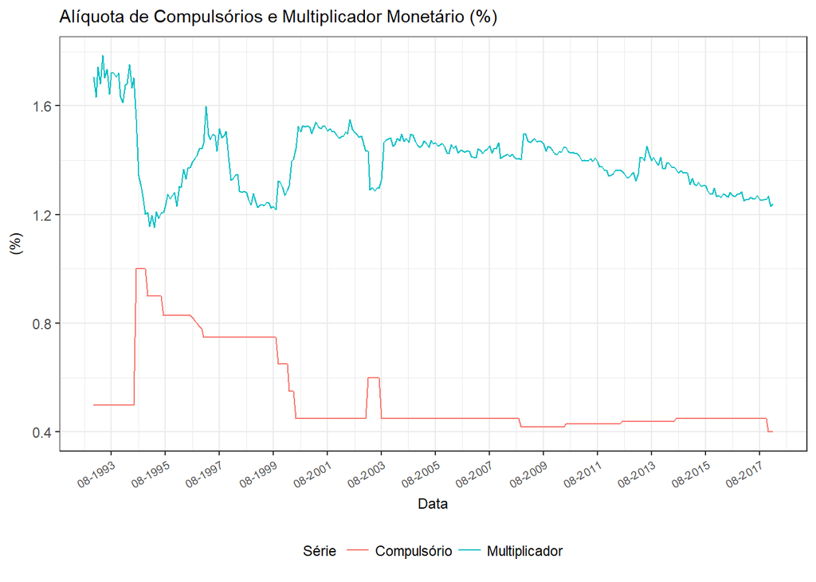

```r
p6 <- ggplot(df5, aes(Data))+
        geom_line(aes(y = Compulsorio, colour = "Compulsório")) +
        geom_line(aes(y = Multiplicador, colour = "Multiplicador")) +
        scale_x_date(date_breaks = "24 months", name = "Data", labels = date_format("%m-%Y"))+
        scale_y_continuous(name = "(%)")+
        theme_bw() +
        theme(axis.text.x = element_text(angle=30, hjust = 1, size = 7), title = element_text(size = 9), legend.position = "bottom")+
        labs(title = "Alíquota de Compulsórios e Multiplicador Monetário (%)", colour = "Série")

p6
```